# Introduction to the `clinUtils` package

Laure Cougnaud and Michela Pasetto

December 04, 2025

# 1 Introduction

This package `clinUtils` contains functionalities to facilitate the analysis of clinical datasets in R.

```r
library(clinUtils)

# packages required for the examples in the vignette
library(ggplot2)
library(pander)
library(htmltools)
library(plyr)
```

Please note that the interactive outputs (table/visualization) in this vignette are only included if [Pandoc](https://pandoc.org/) is available (pre-requisite for R Markdown).

# 2 Data pre-processing

## 2.1 Data import

The [`haven`](https://cran.r-project.org/package=haven) R package enables to load SAS datasets in `sas7bdat` and `xpt` formats.

The function `loadDataADaMSDTM` is a wrapper to import multiple SAS datasets in `sas7bdat` or `xpt` format at once. It returns a list of dataset (once by domain). The variable labels are combined across datasets and available in a dedicated attribute.

```r
pathExampleDatasets <- list.files(
    path = system.file("extdata", "cdiscpilot01", "SDTM", package = "clinUtils"),
    pattern = "*.xpt",
    full.names = TRUE
)

data <- loadDataADaMSDTM(files = pathExampleDatasets)
# A list is returned, each separated file is accessible via data$[fileName]
pander(head(data$DM, 2))
```

Table continues below

| STUDYID | DOMAIN | USUBJID | SUBJID | RFSTDTC | RFENDTC |
| --- | --- | --- | --- | --- | --- |
| CDISCPILOT01 | DM | 01-701-1148 | 1148 | 2013-08-23 | 2014-02-20 |
| CDISCPILOT01 | DM | 01-701-1192 | 1192 | 2012-07-22 | 2013-01-20 |

Table continues below

| RFXSTDTC | RFXENDTC | RFICDTC | RFPENDTC | DTHDTC | DTHFL | SITEID |
| --- | --- | --- | --- | --- | --- | --- |
| 2013-08-23 | 2014-02-20 |  | 2014-02-20T15:07 |  |  | 701 |
| 2012-07-22 | 2013-01-20 |  | 2013-01-20T15:47 |  |  | 701 |

Table continues below

| AGE | AGEU | SEX | RACE | ETHNIC | ARMCD |
| --- | --- | --- | --- | --- | --- |
| 57 | YEARS | M | WHITE | NOT HISPANIC OR LATINO | Xan_Hi |
| 80 | YEARS | F | WHITE | NOT HISPANIC OR LATINO | Xan_Lo |

Table continues below

| ARM | ACTARMCD | ACTARM | COUNTRY | DMDTC |
| --- | --- | --- | --- | --- |
| Xanomeline High Dose | Xan_Hi | Xanomeline High Dose | USA | 2013-08-14 |
| Xanomeline Low Dose | Xan_Lo | Xanomeline Low Dose | USA | 2012-07-08 |

| DMDY | DATASET |
| --- | --- |
| -9 | DM |
| -14 | DM |

```r
pander(head(data$LB, 2))
```

Table continues below

| STUDYID | DOMAIN | USUBJID | LBSEQ | LBTESTCD | LBTEST | LBCAT |
| --- | --- | --- | --- | --- | --- | --- |
| CDISCPILOT01 | LB | 01-701-1148 | 1 | ALB | Albumin | CHEMISTRY |
| CDISCPILOT01 | LB | 01-701-1148 | 38 | ALB | Albumin | CHEMISTRY |

Table continues below

| LBORRES | LBORRESU | LBORNRLO | LBORNRHI | LBSTRESC | LBSTRESN | LBSTRESU |
| --- | --- | --- | --- | --- | --- | --- |
| 4.1 | g/dL | 3.3 | 4.9 | 41 | 41 | g/L |
| 3.9 | g/dL | 3.3 | 4.9 | 39 | 39 | g/L |

Table continues below

| LBSTNRLO | LBSTNRHI | LBNRIND | LBBLFL | VISITNUM | VISIT | VISITDY |
| --- | --- | --- | --- | --- | --- | --- |
| 33 | 49 | NORMAL | Y | 1 | SCREENING 1 | -7 |
| 33 | 49 | NORMAL |  | 4 | WEEK 2 | 14 |

| LBDTC | LBDY | DATASET |
| --- | --- | --- |
| 2013-08-14T13:04 | -9 | LB |
| 2013-09-05T15:43 | 14 | LB |

```r
pander(head(data$AE, 2))
```

Table continues below

| STUDYID | DOMAIN | USUBJID | AESEQ | AESPID |
| --- | --- | --- | --- | --- |
| CDISCPILOT01 | AE | 01-701-1148 | 10 | E27 |
| CDISCPILOT01 | AE | 01-701-1148 | 1 | E20 |

Table continues below

| AETERM | AELLT | AELLTCD |
| --- | --- | --- |
| ACTINIC KERATOSIS | ACTINIC KERATOSIS | NA |
| APPLICATION SITE ERYTHEMA | APPLICATION SITE REDNESS | NA |

Table continues below

| AEDECOD | AEPTCD | AEHLT | AEHLTCD | AEHLGT | AEHLGTCD |
| --- | --- | --- | --- | --- | --- |
| ACTINIC KERATOSIS | NA | HLT_0609 | NA | HLGT_0490 | NA |
| APPLICATION SITE ERYTHEMA | NA | HLT_0617 | NA | HLGT_0152 | NA |

Table continues below

| AEBODSYS | AEBDSYCD | AESOC |
| --- | --- | --- |
| SKIN AND SUBCUTANEOUS TISSUE DISORDERS | NA | SKIN AND SUBCUTANEOUS TISSUE DISORDERS |
| GENERAL DISORDERS AND ADMINISTRATION SITE CONDITIONS | NA | GENERAL DISORDERS AND ADMINISTRATION SITE CONDITIONS |

Table continues below

| AESOCCD | AESEV | AESER | AEACN | AEREL | AEOUT |
| --- | --- | --- | --- | --- | --- |
| NA | MILD | N |  | NONE | NOT RECOVERED/NOT RESOLVED |
| NA | MILD | N |  | PROBABLE | NOT RECOVERED/NOT RESOLVED |

Table continues below

| AESCAN | AESCONG | AESDISAB | AESDTH | AESHOSP | AESLIFE | AESOD | AEDTC |
| --- | --- | --- | --- | --- | --- | --- | --- |
| N | N | N | N | N | N | N | 2014-02-20 |
| N | N | N | N | N | N | N | 2013-09-05 |

| AESTDTC | AEENDTC | AESTDY | AEENDY | DATASET |
| --- | --- | --- | --- | --- |
| 2014-02-12 |  | 174 | NA | AE |
| 2013-08-25 |  | 3 | NA | AE |

```r
# Access labels for all variables
labelVars <- attr(data, "labelVars")
head(labelVars)
```

```
##                               STUDYID                                DOMAIN
##                    "Study Identifier"                 "Domain Abbreviation"
##                               USUBJID                                 AESEQ
##           "Unique Subject Identifier"                     "Sequence Number"
##                                AESPID                                AETERM
##          "Sponsor-Defined Identifier" "Reported Term for the Adverse Event"
```

```r
# Access label for a particular variable:
labelVars["USUBJID"]
```

```
##                     USUBJID
## "Unique Subject Identifier"
```

## 2.2 Example datasets

To demonstrate the functionalities of this package, a subset of the datasets from the CDISC Pilot 01 study is available in the package as dataset.

### 2.2.1 ADaM

```r
# load data
data(dataADaMCDISCP01)
dataADaM <- dataADaMCDISCP01
names(dataADaM)
```

```
## [1] "ADAE"     "ADCM"     "ADLBC"    "ADPP"     "ADQSADAS" "ADQSCIBC" "ADQSNPIX"
## [8] "ADSL"     "ADVS"
```

```r
pander(head(dataADaM$ADSL, 2))
```

Table continues below

| STUDYID | USUBJID | SUBJID | SITEID | SITEGR1 | ARM |
| --- | --- | --- | --- | --- | --- |
| CDISCPILOT01 | 01-701-1148 | 1148 | 701 | 701 | Xanomeline High Dose |
| CDISCPILOT01 | 01-701-1192 | 1192 | 701 | 701 | Xanomeline Low Dose |

Table continues below

| TRT01P | TRT01PN | TRT01A | TRT01AN | TRTSDT |
| --- | --- | --- | --- | --- |
| Xanomeline High Dose | 81 | Xanomeline High Dose | 81 | 2013-08-23 |
| Xanomeline Low Dose | 54 | Xanomeline Low Dose | 54 | 2012-07-22 |

Table continues below

| TRTEDT | TRTDUR | AVGDD | CUMDOSE | AGE | AGEGR1 | AGEGR1N | AGEU | RACE |
| --- | --- | --- | --- | --- | --- | --- | --- | --- |
| 2014-02-20 | 182 | 77.1 | 14040 | 57 | <65 | 1 | YEARS | WHITE |
| 2013-01-20 | 183 | 54 | 9882 | 80 | 65-80 | 2 | YEARS | WHITE |

Table continues below

| RACEN | SEX | ETHNIC | SAFFL | ITTFL | EFFFL | COMP8FL |
| --- | --- | --- | --- | --- | --- | --- |
| 1 | M | NOT HISPANIC OR LATINO | Y | Y | Y | Y |
| 1 | F | NOT HISPANIC OR LATINO | Y | Y | Y | Y |

Table continues below

| COMP16FL | COMP24FL | DISCONFL | DSRAEFL | DTHFL | BMIBL | BMIBLGR1 | HEIGHTBL |
| --- | --- | --- | --- | --- | --- | --- | --- |
| Y | Y |  |  |  | 28.3 | 25-<30 | 175.3 |
| Y | Y |  |  |  | 27.8 | 25-<30 | 151.1 |

Table continues below

| WEIGHTBL | EDUCLVL | DISONSDT | DURDIS | DURDSGR1 | VISIT1DT | RFSTDTC |
| --- | --- | --- | --- | --- | --- | --- |
| 87.1 | 15 | 2010-12-12 | 32.1 | >=12 | 2013-08-14 | 2013-08-23 |
| 63.5 | 12 | 2009-03-15 | 39.8 | >=12 | 2012-07-08 | 2012-07-22 |

| RFENDTC | VISNUMEN | RFENDT | DCDECOD | DCREASCD | MMSETOT | DATASET |
| --- | --- | --- | --- | --- | --- | --- |
| 2014-02-20 | 12 | 2014-02-20 | COMPLETED | Completed | 21 | ADSL |
| 2013-01-20 | 12 | 2013-01-20 | COMPLETED | Completed | 23 | ADSL |

```r
pander(head(dataADaM$ADLBC, 2))
```

Table continues below

| STUDYID | SUBJID | USUBJID | TRTP | TRTPN |
| --- | --- | --- | --- | --- |
| CDISCPILOT01 | 1148 | 01-701-1148 | Xanomeline High Dose | 81 |
| CDISCPILOT01 | 1148 | 01-701-1148 | Xanomeline High Dose | 81 |

Table continues below

| TRTA | TRTAN | TRTSDT | TRTEDT | AGE | AGEGR1 |
| --- | --- | --- | --- | --- | --- |
| Xanomeline High Dose | 81 | 2013-08-23 | 2014-02-20 | 57 | <65 |
| Xanomeline High Dose | 81 | 2013-08-23 | 2014-02-20 | 57 | <65 |

Table continues below

| AGEGR1N | RACE | RACEN | SEX | COMP24FL | DSRAEFL | SAFFL | AVISIT |
| --- | --- | --- | --- | --- | --- | --- | --- |
| 1 | WHITE | 1 | M | Y |  | Y | Baseline |
| 1 | WHITE | 1 | M | Y |  | Y | Baseline |

Table continues below

| AVISITN | ADY | ADT | VISIT | VISITNUM | PARAM |
| --- | --- | --- | --- | --- | --- |
| 0 | -9 | 2013-08-14 | SCREENING 1 | 1 | Sodium (mmol/L) |
| 0 | -9 | 2013-08-14 | SCREENING 1 | 1 | Potassium (mmol/L) |

Table continues below

| PARAMCD | PARAMN | PARCAT1 | AVAL | BASE | CHG | A1LO | A1HI | R2A1LO | R2A1HI |
| --- | --- | --- | --- | --- | --- | --- | --- | --- | --- |
| SODIUM | 18 | CHEM | 139 | 139 | NA | 132 | 147 | 1.053 | 0.9456 |
| K | 19 | CHEM | 4 | 4 | NA | 3.4 | 5.4 | 1.176 | 0.7407 |

Table continues below

| BR2A1LO | BR2A1HI | ANL01FL | ALBTRVAL | ANRIND | BNRIND | ABLFL | AENTMTFL |
| --- | --- | --- | --- | --- | --- | --- | --- |
| 1.053 | 0.9456 |  | 81.5 | N | N | Y |  |
| 1.176 | 0.7407 |  | 4.1 | N | N | Y |  |

| LBSEQ | LBNRIND | LBSTRESN | DATASET |
| --- | --- | --- | --- |
| 26 | NORMAL | 139 | ADLBC |
| 19 | NORMAL | 4 | ADLBC |

```r
pander(head(dataADaM$ADAE, 2))
```

Table continues below

| STUDYID | SITEID | USUBJID | TRTA | TRTAN | AGE |
| --- | --- | --- | --- | --- | --- |
| CDISCPILOT01 | 701 | 01-701-1148 | Xanomeline High Dose | 81 | 57 |
| CDISCPILOT01 | 701 | 01-701-1148 | Xanomeline High Dose | 81 | 57 |

Table continues below

| AGEGR1 | AGEGR1N | RACE | RACEN | SEX | SAFFL | TRTSDT | TRTEDT |
| --- | --- | --- | --- | --- | --- | --- | --- |
| <65 | 1 | WHITE | 1 | M | Y | 2013-08-23 | 2014-02-20 |
| <65 | 1 | WHITE | 1 | M | Y | 2013-08-23 | 2014-02-20 |

Table continues below

| ASTDT | ASTDTF | ASTDY | AENDT | AENDY | ADURN | ADURU |
| --- | --- | --- | --- | --- | --- | --- |
| 2013-08-25 |  | 3 | NA | NA | NA |  |
| 2013-08-25 |  | 3 | NA | NA | NA |  |

Table continues below

| AETERM | AELLT | AELLTCD |
| --- | --- | --- |
| APPLICATION SITE ERYTHEMA | APPLICATION SITE REDNESS | NA |
| APPLICATION SITE PRURITUS | APPLICATION SITE ITCHING | NA |

Table continues below

| AEDECOD | AEPTCD | AEHLT | AEHLTCD | AEHLGT | AEHLGTCD |
| --- | --- | --- | --- | --- | --- |
| APPLICATION SITE ERYTHEMA | NA | HLT_0617 | NA | HLGT_0152 | NA |
| APPLICATION SITE PRURITUS | NA | HLT_0317 | NA | HLGT_0338 | NA |

Table continues below

| AEBODSYS | AESOC | AESOCCD |
| --- | --- | --- |
| GENERAL DISORDERS AND ADMINISTRATION SITE CONDITIONS | GENERAL DISORDERS AND ADMINISTRATION SITE CONDITIONS | NA |
| GENERAL DISORDERS AND ADMINISTRATION SITE CONDITIONS | GENERAL DISORDERS AND ADMINISTRATION SITE CONDITIONS | NA |

Table continues below

| AESEV | AESER | AESCAN | AESCONG | AESDISAB | AESDTH | AESHOSP | AESLIFE |
| --- | --- | --- | --- | --- | --- | --- | --- |
| MILD | N | N | N | N | N | N | N |
| MILD | N | N | N | N | N | N | N |

Table continues below

| AESOD | AEREL | AEACN | AEOUT | AESEQ | TRTEMFL |
| --- | --- | --- | --- | --- | --- |
| N | PROBABLE |  | NOT RECOVERED/NOT RESOLVED | 1 | Y |
| N | PROBABLE |  | NOT RECOVERED/NOT RESOLVED | 2 | Y |

Table continues below

| AOCCFL | AOCCSFL | AOCCPFL | AOCC02FL | AOCC03FL | AOCC04FL |
| --- | --- | --- | --- | --- | --- |
| Y | Y | Y |  |  |  |
|  |  | Y |  |  |  |

| CQ01NAM | AOCC01FL | DATASET |
| --- | --- | --- |
| DERMATOLOGIC EVENTS | Y | ADAE |
| DERMATOLOGIC EVENTS |  | ADAE |

```r
# and variable labels
labelVarsADaM <- attr(dataADaM, "labelVars")
head(labelVarsADaM)
```

```
##                     STUDYID                      SITEID
##          "Study Identifier"     "Study Site Identifier"
##                     USUBJID                        TRTA
## "Unique Subject Identifier"          "Actual Treatment"
##                       TRTAN                         AGE
##      "Actual Treatment (N)"                       "Age"
```

### 2.2.2 SDTM

```r
# load data
data(dataSDTMCDISCP01)
dataSDTM <- dataSDTMCDISCP01
names(dataSDTM)
```

```
##  [1] "AE"     "CM"     "DM"     "DS"     "EX"     "LB"     "MH"     "QS"
##  [9] "SUPPDM" "SV"     "VS"
```

```r
pander(head(dataSDTM$DM, 2))
```

Table continues below

| STUDYID | DOMAIN | USUBJID | SUBJID | RFSTDTC | RFENDTC |
| --- | --- | --- | --- | --- | --- |
| CDISCPILOT01 | DM | 01-701-1148 | 1148 | 2013-08-23 | 2014-02-20 |
| CDISCPILOT01 | DM | 01-701-1192 | 1192 | 2012-07-22 | 2013-01-20 |

Table continues below

| RFXSTDTC | RFXENDTC | RFICDTC | RFPENDTC | DTHDTC | DTHFL | SITEID |
| --- | --- | --- | --- | --- | --- | --- |
| 2013-08-23 | 2014-02-20 |  | 2014-02-20T15:07 |  |  | 701 |
| 2012-07-22 | 2013-01-20 |  | 2013-01-20T15:47 |  |  | 701 |

Table continues below

| AGE | AGEU | SEX | RACE | ETHNIC | ARMCD |
| --- | --- | --- | --- | --- | --- |
| 57 | YEARS | M | WHITE | NOT HISPANIC OR LATINO | Xan_Hi |
| 80 | YEARS | F | WHITE | NOT HISPANIC OR LATINO | Xan_Lo |

Table continues below

| ARM | ACTARMCD | ACTARM | COUNTRY | DMDTC |
| --- | --- | --- | --- | --- |
| Xanomeline High Dose | Xan_Hi | Xanomeline High Dose | USA | 2013-08-14 |
| Xanomeline Low Dose | Xan_Lo | Xanomeline Low Dose | USA | 2012-07-08 |

| DMDY | DATASET |
| --- | --- |
| -9 | DM |
| -14 | DM |

```r
pander(head(dataSDTM$LB, 2))
```

Table continues below

| STUDYID | DOMAIN | USUBJID | LBSEQ | LBTESTCD | LBTEST | LBCAT |
| --- | --- | --- | --- | --- | --- | --- |
| CDISCPILOT01 | LB | 01-701-1148 | 1 | ALB | Albumin | CHEMISTRY |
| CDISCPILOT01 | LB | 01-701-1148 | 38 | ALB | Albumin | CHEMISTRY |

Table continues below

| LBORRES | LBORRESU | LBORNRLO | LBORNRHI | LBSTRESC | LBSTRESN | LBSTRESU |
| --- | --- | --- | --- | --- | --- | --- |
| 4.1 | g/dL | 3.3 | 4.9 | 41 | 41 | g/L |
| 3.9 | g/dL | 3.3 | 4.9 | 39 | 39 | g/L |

Table continues below

| LBSTNRLO | LBSTNRHI | LBNRIND | LBBLFL | VISITNUM | VISIT | VISITDY |
| --- | --- | --- | --- | --- | --- | --- |
| 33 | 49 | NORMAL | Y | 1 | SCREENING 1 | -7 |
| 33 | 49 | NORMAL |  | 4 | WEEK 2 | 14 |

| LBDTC | LBDY | DATASET |
| --- | --- | --- |
| 2013-08-14T13:04 | -9 | LB |
| 2013-09-05T15:43 | 14 | LB |

```r
pander(head(dataSDTM$AE, 2))
```

Table continues below

| STUDYID | DOMAIN | USUBJID | AESEQ | AESPID |
| --- | --- | --- | --- | --- |
| CDISCPILOT01 | AE | 01-701-1148 | 10 | E27 |
| CDISCPILOT01 | AE | 01-701-1148 | 1 | E20 |

Table continues below

| AETERM | AELLT | AELLTCD |
| --- | --- | --- |
| ACTINIC KERATOSIS | ACTINIC KERATOSIS | NA |
| APPLICATION SITE ERYTHEMA | APPLICATION SITE REDNESS | NA |

Table continues below

| AEDECOD | AEPTCD | AEHLT | AEHLTCD | AEHLGT | AEHLGTCD |
| --- | --- | --- | --- | --- | --- |
| ACTINIC KERATOSIS | NA | HLT_0609 | NA | HLGT_0490 | NA |
| APPLICATION SITE ERYTHEMA | NA | HLT_0617 | NA | HLGT_0152 | NA |

Table continues below

| AEBODSYS | AEBDSYCD | AESOC |
| --- | --- | --- |
| SKIN AND SUBCUTANEOUS TISSUE DISORDERS | NA | SKIN AND SUBCUTANEOUS TISSUE DISORDERS |
| GENERAL DISORDERS AND ADMINISTRATION SITE CONDITIONS | NA | GENERAL DISORDERS AND ADMINISTRATION SITE CONDITIONS |

Table continues below

| AESOCCD | AESEV | AESER | AEACN | AEREL | AEOUT |
| --- | --- | --- | --- | --- | --- |
| NA | MILD | N |  | NONE | NOT RECOVERED/NOT RESOLVED |
| NA | MILD | N |  | PROBABLE | NOT RECOVERED/NOT RESOLVED |

Table continues below

| AESCAN | AESCONG | AESDISAB | AESDTH | AESHOSP | AESLIFE | AESOD | AEDTC |
| --- | --- | --- | --- | --- | --- | --- | --- |
| N | N | N | N | N | N | N | 2014-02-20 |
| N | N | N | N | N | N | N | 2013-09-05 |

| AESTDTC | AEENDTC | AESTDY | AEENDY | DATASET |
| --- | --- | --- | --- | --- |
| 2014-02-12 |  | 174 | NA | AE |
| 2013-08-25 |  | 3 | NA | AE |

```r
# and variable labels
labelVarsSDTM <- attr(dataSDTM, "labelVars")
head(labelVarsSDTM)
```

```
##                               STUDYID                                DOMAIN
##                    "Study Identifier"                 "Domain Abbreviation"
##                               USUBJID                                 AESEQ
##           "Unique Subject Identifier"                     "Sequence Number"
##                                AESPID                                AETERM
##          "Sponsor-Defined Identifier" "Reported Term for the Adverse Event"
```

## 2.3 Variable labels

Typical data stored in SAS contains the label for each variable available in the dataset.

The function `getLabelVar` extracts the label for the specified variable(s), ensuring that the variable code is used if no label is specified.

```r
# variable label is extracted from 'labelVars'
getLabelVar(var = "AEDECOD", labelVars = labelVars)
```

```
##                   AEDECOD
## "Dictionary-Derived Term"
```

This function also supports extraction of variable labels from the ‘label’ attribute of the column, as in the tibble as returned by the `read_sas`/`read_xpt` functions from the `haven` package.

## 2.4 Get parameter label from its parameter code

In typical basic CDISC dataset (a.k.a BDS: Basic Data Structure), as laboratory, vital signs datasets, variables are available to store parameter and parameter code (`PARAM`/`PARAMCD` in ADaM).

The function `getLabelParamcd` get the label from specific parameter(s) code.

Variables with parameter name and code are based by default on standard ADaM CDISC parameter variables (`PARAM`/`PARAMCD`).

```r
# For ADaM dataset
getLabelParamcd(paramcd = "CHOL", data = dataADaM$ADLB)
```

```
##                   CHOL
## "Cholesterol (mmol/L)"
```

```r
getLabelParamcd(paramcd = "BILI", data = dataADaM$ADLB)
```

```
##                 BILI
## "Bilirubin (umol/L)"
```

```r
# For SDTM dataset
getLabelParamcd(paramcd = "CHOL", data = dataSDTM$LB, paramcdVar = "LBTESTCD", paramVar = "LBTEST")
```

```
##          CHOL
## "Cholesterol"
```

```r
getLabelParamcd(paramcd = "BILI", data = dataSDTM$LB, paramcdVar = "LBTESTCD", paramVar = "LBTEST")
```

```
##        BILI
## "Bilirubin"
```

# 3 Visualizations

## 3.1 Palette for CDISC variables

Palette for typical CDISC-variable(s) are available in the package.

### 3.1.1 Normal reference range indicators

Meaningful colors and symbols for a Normal Reference Range Indicator CDISC variable (`-NRIND`) are extracted via the `colorPaletteNRIND` and `shapePaletteNRIND` respectively:

```r
print(colorPaletteNRIND)
```

```
##      LOW   NORMAL     HIGH ABNORMAL  UNKNOWN       NA
## "orange" "green4" "orange"    "red"   "grey"   "grey"
```

```r
print(shapePaletteNRIND)
```

```
##      LOW   NORMAL     HIGH ABNORMAL  UNKNOWN       NA
##       25       21       24       18        3        3
```

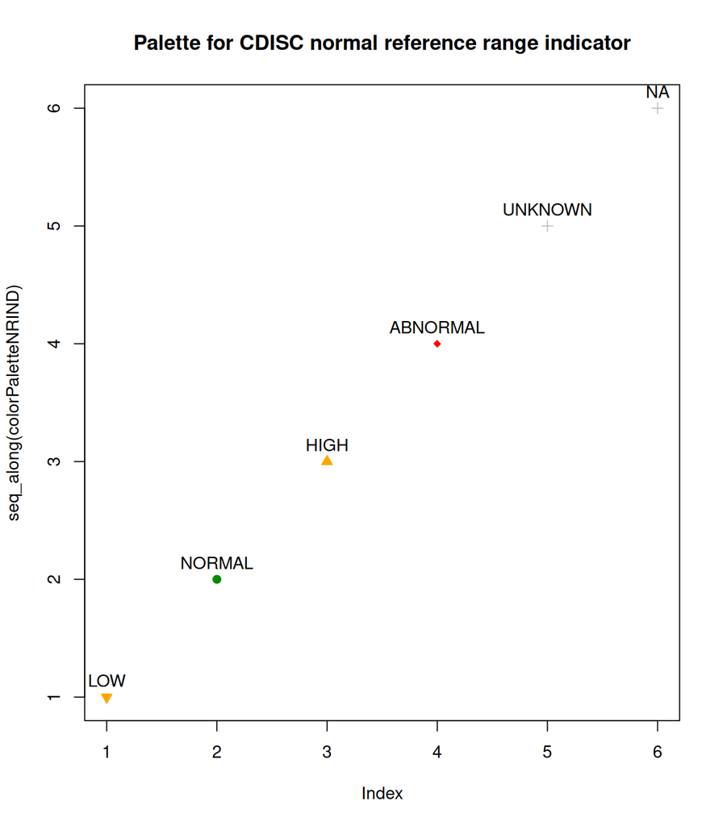

```r
plot(
    x = seq_along(colorPaletteNRIND),
    col = colorPaletteNRIND,
    bg = colorPaletteNRIND,
    pch = shapePaletteNRIND
)
text(
    x = seq_along(colorPaletteNRIND),
    labels = names(colorPaletteNRIND), pos = 3
)
title("Palette for CDISC normal reference range indicator")
```

The `getPaletteCDISC` function extracts such palette for a specified variable.

This retains only the categories available in the variable, and ensures that extra symbols are extracted in case non standard categories are available in the data.

```r
dataPlot <- subset(dataSDTM$LB, LBTEST == "Leukocytes")

colorPalette <- getPaletteCDISC(x = dataPlot$LBNRIND, var = "NRIND", type = "color")
print(colorPalette)
```

```
##      LOW   NORMAL     HIGH
## "orange" "green4" "orange"
```

```r
shapePalette <- getPaletteCDISC(x = dataPlot$LBNRIND, var = "NRIND", type = "shape")
print(shapePalette)
```

```
##    LOW NORMAL   HIGH
##     25     21     24
```

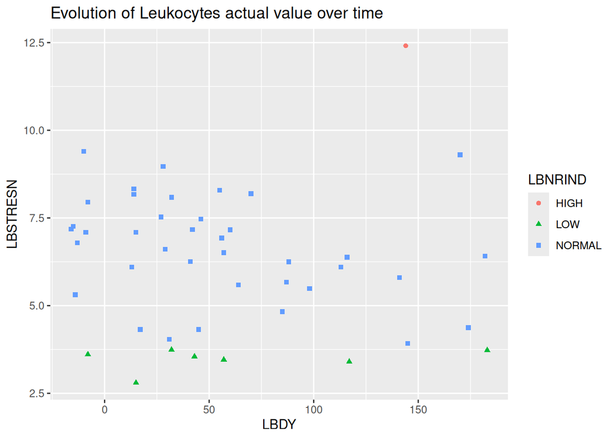

```r
# visualize profile over time
gg <- ggplot(data = dataPlot) +
    geom_point(aes(x = LBDY, y = LBSTRESN,
            color = LBNRIND, fill = LBNRIND, shape = LBNRIND)) +
    ggtitle("Evolution of Leukocytes actual value over time")
print(gg)
```

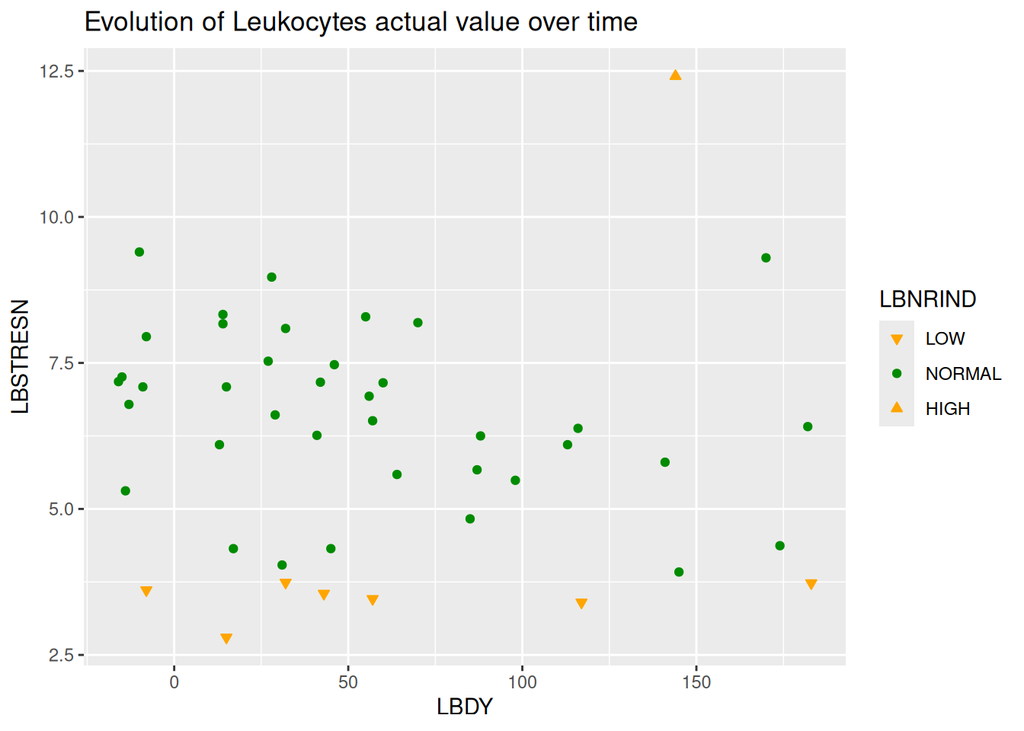

```r
# use 'standard' symbols/colors
# ('limits' is only required if the categories are not already ordered in LBNRIND)
gg +
    scale_color_manual(values = colorPalette, limits = names(colorPalette)) +
    scale_fill_manual(values = colorPalette, limits = names(colorPalette)) +
    scale_shape_manual(values = shapePalette, limits = names(colorPalette))
```

## 3.2 Get default palettes

Default palettes for visualizations are included in the package.

Palettes can be extracted based on a variable, or number of elements.

These packages are included for consistency across the entire suite of R packages.

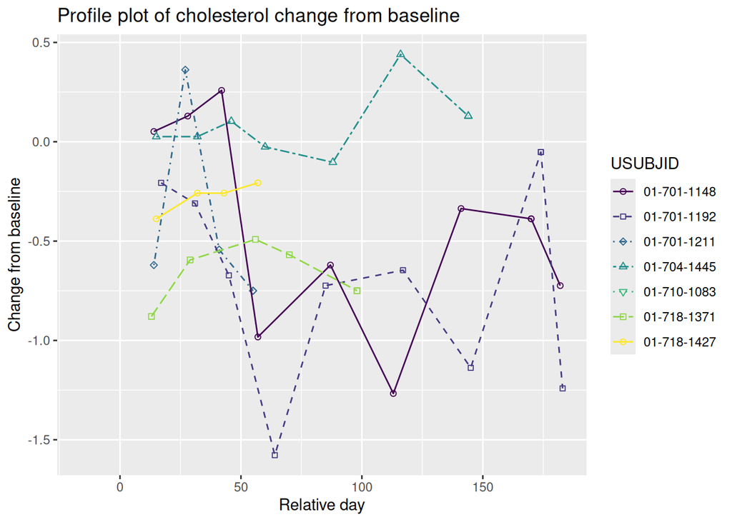

```r
dataPlot <- subset(dataADaM$ADLB, PARAMCD == "CHOL")

# extract palettes
colorPalette <- getColorPalette(x = dataPlot$USUBJID)
shapePalette <- getShapePalette(x = dataPlot$USUBJID)
linetypePalette <- getLinetypePalette(x = dataPlot$USUBJID)

# create the plot
ggplot(data = dataPlot, aes(x = ADY, y = CHG, color = USUBJID)) +
    geom_point(aes(shape = USUBJID)) +
    geom_line(aes(linetype = USUBJID, group = USUBJID)) +
    scale_color_manual(values = colorPalette) +
    scale_shape_manual(values = shapePalette) +
    scale_linetype_manual(values = linetypePalette) +
    labs(x = "Relative day", y = "Change from baseline",
        title = "Profile plot of cholesterol change from baseline")
```

Custom palettes can be specified via the `palette` parameter.

# 4 Tables

## 4.1 Rounding

In R, numbers are by default rounded to the even digit for rounding off a 5.

Numbers can be rounded based on the ‘rounding up’ strategy for rounding off a 5 with `roundHalfUp` & `roundHalfUpTextFormat`. This is useful when statistics created with the `SAS` software should be reproduced in R.

```r
# round up
roundHalfUp(c(0.45, 0.55), 1)
```

```
## [1] 0.5 0.6
```

```r
# versus R default:
round(c(0.45, 0.55), 1)
```

```
## [1] 0.4 0.6
```

## 4.2 Display data in an interactive table

The `getClinDT` function is an utility function, based on the the DT package, with sensitive default settings and extra common functionalities of interest for data in clinical trials, as listing or summary tables of descriptive statistics.

There are built-in functionalities to expand row variable(s) to display patient-specific information or include bar visualization.

```r
dataTEAE <- subset(dataADaM$ADAE, SAFFL == "Y" & TRTEMFL == "Y")

# set column names to labels
labelVarsTEAE <- getLabelVar(
    var = colnames(dataTEAE),
    labelVars = labelVarsADaM
)
colnamesTEAE <- setNames(names(labelVarsTEAE), labelVarsTEAE)

dataTEAE <- dataTEAE[order(dataTEAE$AESOC), ]
```

```r
getClinDT(
    dataTEAE,
    colnames = colnamesTEAE,
    rowGroupVar = c("AESOC"),
    barVar = "AGE",
    barRange = c(0, 100),
    caption = "Listing of treatment-emergent adverse events on the safety analysis set"
)
```

| Study Identifier | Study Site Identifier | Unique Subject Identifier | Actual Treatment | Actual Treatment (N) | Age | Pooled Age Group 1 | Pooled Age Group 1 (N) | Race | Race (N) | Sex | Safety Population Flag | Date of First Exposure to Treatment | Date of Last Exposure to Treatment | Analysis Start Date | Analysis Start Date Imputation Flag | Analysis Start Relative Day | Analysis End Date | Analysis End Relative Day | AE Duration (N) | AE Duration Units | Reported Term for the Adverse Event | Lowest Level Term | Lowest Level Term Code | Dictionary-Derived Term | Preferred Term Code | High Level Term | High Level Term Code | High Level Group Term | High Level Group Term Code | … |
| --- | --- | --- | --- | --- | --- | --- | --- | --- | --- | --- | --- | --- | --- | --- | --- | --- | --- | --- | --- | --- | --- | --- | --- | --- | --- | --- | --- | --- | --- | --- |
| CDISCPILOT01 | 710 | 01-710-1083 | Placebo | 0 | 89 | &gt;80 | 3 | WHITE | 1 | F | Y | 2013-07-22 | 2013-08-01 | 2013-08-02 |  | 12 | 2013-08-02 | 12 | 1 | DAY | MYOCARDIAL INFARCTION | MYOCARDIAL INFARCT |  | MYOCARDIAL INFARCTION |  | HLT_0649 |  | HLGT_0688 |  | … |
| CDISCPILOT01 | 718 | 01-718-1371 | Xanomeline High Dose | 81 | 69 | 65-80 | 2 | WHITE | 1 | F | Y | 2013-04-26 | 2013-08-01 | 2013-05-09 |  | 14 | 2013-05-11 | 16 | 3 | DAY | NAUSEA | NAUSEA |  | NAUSEA |  | HLT_0742 |  | HLGT_0326 |  | … |
| CDISCPILOT01 | 718 | 01-718-1427 | Xanomeline High Dose | 81 | 74 | 65-80 | 2 | BLACK OR AFRICAN AMERICAN | 2 | F | Y | 2012-12-17 | 2013-02-11 | 2012-12-26 |  | 10 | 2012-12-26 | 10 | 1 | DAY | NAUSEA | NAUSEA |  | NAUSEA |  | HLT_0742 |  | HLGT_0326 |  | … |
| CDISCPILOT01 | 718 | 01-718-1427 | Xanomeline High Dose | 81 | 74 | 65-80 | 2 | BLACK OR AFRICAN AMERICAN | 2 | F | Y | 2012-12-17 | 2013-02-11 | 2013-01-03 |  | 18 | 2013-01-09 | 24 | 7 | DAY | NAUSEA | NAUSEA |  | NAUSEA |  | HLT_0742 |  | HLGT_0326 |  | … |
| CDISCPILOT01 | 718 | 01-718-1427 | Xanomeline High Dose | 81 | 74 | 65-80 | 2 | BLACK OR AFRICAN AMERICAN | 2 | F | Y | 2012-12-17 | 2013-02-11 | 2013-01-16 |  | 31 | 2013-01-16 | 31 | 1 | DAY | NAUSEA | NAUSEA |  | NAUSEA |  | HLT_0742 |  | HLGT_0326 |  | … |
| CDISCPILOT01 | 718 | 01-718-1427 | Xanomeline High Dose | 81 | 74 | 65-80 | 2 | BLACK OR AFRICAN AMERICAN | 2 | F | Y | 2012-12-17 | 2013-02-11 | 2013-01-21 |  | 36 | 2013-01-24 | 39 | 4 | DAY | NAUSEA | NAUSEA |  | NAUSEA |  | HLT_0742 |  | HLGT_0326 |  | … |
| CDISCPILOT01 | 718 | 01-718-1427 | Xanomeline High Dose | 81 | 74 | 65-80 | 2 | BLACK OR AFRICAN AMERICAN | 2 | F | Y | 2012-12-17 | 2013-02-11 | 2013-02-04 |  | 50 | 2013-02-25 | 71 | 22 | DAY | NAUSEA | NAUSEA |  | NAUSEA |  | HLT_0742 |  | HLGT_0326 |  | … |
| CDISCPILOT01 | 718 | 01-718-1427 | Xanomeline High Dose | 81 | 74 | 65-80 | 2 | BLACK OR AFRICAN AMERICAN | 2 | F | Y | 2012-12-17 | 2013-02-11 | 2013-02-04 |  | 50 | 2013-02-25 | 71 | 22 | DAY | NAUSEA | NAUSEA |  | NAUSEA |  | HLT_0742 |  | HLGT_0326 |  | … |
| CDISCPILOT01 | 701 | 01-701-1148 | Xanomeline High Dose | 81 | 57 | &lt;65 | 1 | WHITE | 1 | M | Y | 2013-08-23 | 2014-02-20 | 2013-08-25 |  | 3 |  |  |  |  | APPLICATION SITE ERYTHEMA | APPLICATION SITE REDNESS |  | APPLICATION SITE ERYTHEMA |  | HLT_0617 |  | HLGT_0152 |  | … |
| CDISCPILOT01 | 701 | 01-701-1148 | Xanomeline High Dose | 81 | 57 | &lt;65 | 1 | WHITE | 1 | M | Y | 2013-08-23 | 2014-02-20 | 2013-08-25 |  | 3 |  |  |  |  | APPLICATION SITE PRURITUS | APPLICATION SITE ITCHING |  | APPLICATION SITE PRURITUS |  | HLT_0317 |  | HLGT_0338 |  | … |

[output cut: 44 more lines]

## 4.3 Comparison of tables

In clinical trials, datasets are typically delivered in successive batches, depending on the patient recruitment and the different milestones of the study.

The changes between successive data deliveries can be compared with the `compareTables` function.

```r
# Build example dataset with treatment-emergent adverse events
# of multiple batches

varsListing <- c("USUBJID", "AESOC", "AEDECOD", "ASTDT", "AESEV", "AEOUT")
dataTEAEListing <- dataTEAE[, varsListing]

# simulate removal of observations in new batch
dataTEAENew <- dataTEAE[-sample.int(n = nrow(dataTEAEListing), size = 3), ]

# simulate addition of observations in new batch
dataTEAEOld <- dataTEAE[-sample.int(n = nrow(dataTEAEListing), size = 3), ]

# simulate change of observations
dataTEAEOld[seq_len(2), "AESEV"] <- "SEVERE"

refVars <- c("USUBJID", "AESOC", "AEDECOD", "ASTDT")
tableComparison <- compareTables(
    newData = dataTEAENew,
    oldData = dataTEAEOld,
    referenceVars = refVars,
    changeableVars = setdiff(colnames(dataTEAEListing), refVars),
    # parameters passed to datatable
    colnames = setNames(names(labelVarsADaM), labelVarsADaM)
)
```

The new, old datasets with change information, or the difference between datasets are extracted. See documentation of `outputType` parameter for further details.

The table below highlight the differences between the datasets in an interactive table.

```r
tableComparison$`table-comparison-interactive`
```

| Comparison type | Version | Unique Subject Identifier | Primary System Organ Class | Dictionary-Derived Term | Analysis Start Date | Severity/Intensity | Outcome of Adverse Event | USUBJID.diff | AESOC.diff | AEDECOD.diff | ASTDT.diff | AESEV.diff | AEOUT.diff |
| --- | --- | --- | --- | --- | --- | --- | --- | --- | --- | --- | --- | --- | --- |
| Addition | Current | 01-701-1192 | GENERAL DISORDERS AND ADMINISTRATION SITE CONDITIONS | APPLICATION SITE IRRITATION | 2012-12-05 | MILD | NOT RECOVERED/NOT RESOLVED | + | + | + | + | + | + |
| Addition | Current | 01-701-1211 | MUSCULOSKELETAL AND CONNECTIVE TISSUE DISORDERS | SHOULDER PAIN | 2012-11-21 | MILD | NOT RECOVERED/NOT RESOLVED | + | + | + | + | + | + |
| Addition | Current | 01-701-1211 | PSYCHIATRIC DISORDERS | CONFUSIONAL STATE | 2013-01-11 | MODERATE | NOT RECOVERED/NOT RESOLVED | + | + | + | + | + | + |
| Removal | Previous | 01-701-1211 | RENAL AND URINARY DISORDERS | INCONTINENCE | 2012-11-22 | MILD | NOT RECOVERED/NOT RESOLVED | - | - | - | - | - | - |
| Change | Current | 01-718-1371 | GASTROINTESTINAL DISORDERS | NAUSEA | 2013-05-09 | MILD | RECOVERED/RESOLVED | == | == | == | == | != | == |
| Change | Previous | 01-718-1371 | GASTROINTESTINAL DISORDERS | NAUSEA | 2013-05-09 | SEVERE | RECOVERED/RESOLVED | == | == | == | == | != | == |
| Removal | Previous | 01-718-1371 | NERVOUS SYSTEM DISORDERS | PARTIAL SEIZURES WITH SECONDARY GENERALISATION | 2013-06-02 | SEVERE | RECOVERED/RESOLVED | - | - | - | - | - | - |
| Removal | Previous | 01-718-1427 | MUSCULOSKELETAL AND CONNECTIVE TISSUE DISORDERS | BACK PAIN | 2012-12-18 | MILD | RECOVERED/RESOLVED | - | - | - | - | - | - |

# 5 Reporting

## 5.1 Include list of objects in a *Rmarkdown* document

Dedicated functions: `knitPrintListPlots` and `knitPrintListObjects` are available to include a list of plots/objects in a `Rmarkdown` document, enabling to specify any (knitr) chunk options and title header for each object.

This function inserts each object in a separated code chunk, such as independent option (as figure dimensions) can be specified for each object.

Please note that this function should be used within a chunk having the option: **`results = 'asis'`**.

### 5.1.1 Static visualizations (`ggplot2`)

For example, by default in knitr the options to specify figure dimensions should be the same for all plots generated from the same chunk (`fig.height`/`fig.width`).

Plots can be included with different specified dimension with: `knitPrintListPlots`.

```r
dataLB <- subset(dataSDTM$LB,
    LBTESTCD %in% c("ALB", "ALT", "CHOL", "HCT", "KETONES", "PH")
)
dataLB$ACTARM <- dataSDTM$DM$ACTARM[match(dataLB$USUBJID, dataSDTM$DM$USUBJID)]

# create plots:
listPlotsLB <- plyr::dlply(dataLB, "LBCAT", function(data)
      ggplot(data = data) +
          geom_histogram(aes(fill = LBNRIND, x = ACTARM), stat = "count", position = "dodge") +
          facet_wrap(~LBTEST) +
          theme(axis.text.x = element_text(angle = -45, hjust = 0))
)
# n2mfrow: extract default dimensions for a specified number of plots
figDim <- plyr::dlply(dataLB, "LBCAT", function(data)
      n2mfrow(length(unique(data$LBTESTCD)))
)
knitPrintListPlots(
    plotsList = listPlotsLB,
    generalLabel = "lab-hist-static",
    type = "ggplot2",
    # set caption for each figure
    fig.cap = paste("Barplot of", tolower(names(listPlotsLB)), "measurements"),
    # specify different dimensions
    fig.width = sapply(figDim, "[[", 1) * 2 + 1, # 3 in for each plot + 1 in for the legend
    fig.height = sapply(figDim, "[[", 2) * 2 + 2, # 3 in for each plot + 2 for x-axis labels
    # include title before each visualization
    titles = simpleCap(tolower(names(listPlotsLB))),
    titleLevel = 4
)
```

#### 5.1.1.1 Chemistry

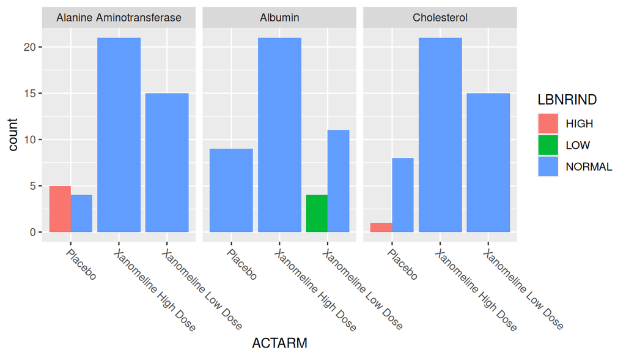

Barplot of chemistry measurements

#### 5.1.1.2 Hematology

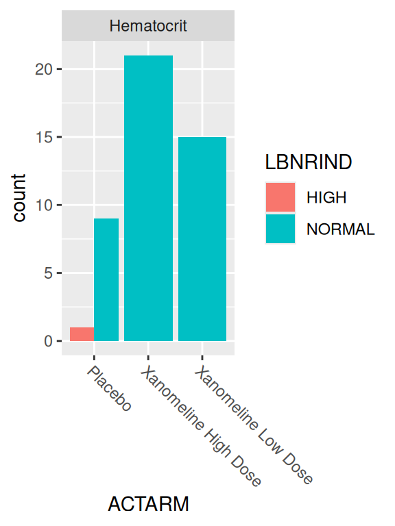

Barplot of hematology measurements

#### 5.1.1.3 Urinalysis

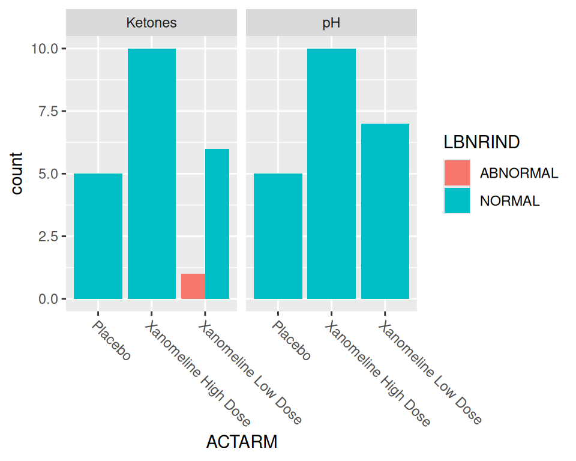

Barplot of urinalysis measurements

### 5.1.2 Interactive visualizations (`plotly`)

A list of interactive figures is created with the `plotly` package:

```r
library(plotly)
listPlotsInteractiveLB <- sapply(listPlotsLB, function(ggplot)
      ggplotly(ggplot) %>% partial_bundle()
    , simplify = FALSE)
```

#### 5.1.2.1 `htmltools::tagList`

A list of interactive figures can be included within a *Rmarkdown* document with the `tagList` function of the `htmltools` package.

```r
tagListArgs <- mapply(list,
    # section header
    lapply(names(listPlotsInteractiveLB), htmltools::h4),
    # interactive plots
    listPlotsInteractiveLB,
    SIMPLIFY = FALSE
)
tagListArgs <- unlist(tagListArgs, recursive = FALSE)
do.call(htmltools::tagList, tagListArgs)
```

#### CHEMISTRY

[interactive chart not shown]

#### HEMATOLOGY

[interactive chart not shown]

#### URINALYSIS

[interactive chart not shown]

#### 5.1.2.2 Inclusion in a separated chunk

The function `knitPrintListPlots` with the `type` set to ‘plotly’ enables to include additionally e.g. a caption or a title.

```r
knitPrintListPlots(
    plotsList = listPlotsInteractiveLB,
    generalLabel = "lab-hist-interactive",
    type = "plotly",
    # include title before each visualization
    titles = simpleCap(tolower(names(listPlotsInteractiveLB))),
    titleLevel = 5
)
```

##### 5.1.2.2.1 Chemistry

[interactive chart not shown]

##### 5.1.2.2.2 Hematology

[interactive chart not shown]

##### 5.1.2.2.3 Urinalysis

[interactive chart not shown]

### 5.1.3 Tables (`flextable`)

The [`flextable`](https://CRAN.R-project.org/package=flextable) package enables to create highly customizable tables for Word/PowerPoint format (among others).

The function `knitPrintListObjects` enables to include a **list of `flextable` objects** within a single chunk.

Please note that the following chunk option should be used: **`results = 'asis'`**.

```r
library(flextable)
listFtLB <- plyr::dlply(dataLB, "LBCAT", function(dataParcat){
      flextable::flextable(data = head(dataParcat))
    })

knitPrintListObjects(
    xList = listFtLB,
    generalLabel = "lab-listing-ft",
    titles = simpleCap(tolower(names(listFtLB))),
    # different alignment for each table
    ft.align = c("center", "right", "left"),
    titleLevel = 4
)
```

#### 5.1.3.1 Chemistry

| STUDYID | DOMAIN | USUBJID | LBSEQ | LBTESTCD | LBTEST | LBCAT | LBORRES | LBORRESU | LBORNRLO | LBORNRHI | LBSTRESC | LBSTRESN | LBSTRESU | LBSTNRLO | LBSTNRHI | LBNRIND | LBBLFL | VISITNUM | VISIT | VISITDY | LBDTC | LBDY | DATASET | ACTARM |
| --- | --- | --- | --- | --- | --- | --- | --- | --- | --- | --- | --- | --- | --- | --- | --- | --- | --- | --- | --- | --- | --- | --- | --- | --- |
| CDISCPILOT01 | LB | 01-701-1148 | 1 | ALB | Albumin | CHEMISTRY | 4.1 | g/dL | 3.3 | 4.9 | 41 | 41 | g/L | 33 | 49 | NORMAL | Y | 1 | SCREENING 1 | -7 | 2013-08-14T13:04 | -9 | LB | Xanomeline High Dose |
| CDISCPILOT01 | LB | 01-701-1148 | 38 | ALB | Albumin | CHEMISTRY | 3.9 | g/dL | 3.3 | 4.9 | 39 | 39 | g/L | 33 | 49 | NORMAL |  | 4 | WEEK 2 | 14 | 2013-09-05T15:43 | 14 | LB | Xanomeline High Dose |
| CDISCPILOT01 | LB | 01-701-1148 | 73 | ALB | Albumin | CHEMISTRY | 3.8 | g/dL | 3.3 | 4.9 | 38 | 38 | g/L | 33 | 49 | NORMAL |  | 5 | WEEK 4 | 28 | 2013-09-19T14:30 | 28 | LB | Xanomeline High Dose |
| CDISCPILOT01 | LB | 01-701-1148 | 103 | ALB | Albumin | CHEMISTRY | 4.1 | g/dL | 3.3 | 4.9 | 41 | 41 | g/L | 33 | 49 | NORMAL |  | 7 | WEEK 6 | 42 | 2013-10-03T12:17 | 42 | LB | Xanomeline High Dose |
| CDISCPILOT01 | LB | 01-701-1148 | 133 | ALB | Albumin | CHEMISTRY | 3.8 | g/dL | 3.3 | 4.9 | 38 | 38 | g/L | 33 | 49 | NORMAL |  | 8 | WEEK 8 | 56 | 2013-10-18T15:46 | 57 | LB | Xanomeline High Dose |
| CDISCPILOT01 | LB | 01-701-1148 | 163 | ALB | Albumin | CHEMISTRY | 3.8 | g/dL | 3.3 | 4.9 | 38 | 38 | g/L | 33 | 49 | NORMAL |  | 9 | WEEK 12 | 84 | 2013-11-17T10:59 | 87 | LB | Xanomeline High Dose |

#### 5.1.3.2 Hematology

| STUDYID | DOMAIN | USUBJID | LBSEQ | LBTESTCD | LBTEST | LBCAT | LBORRES | LBORRESU | LBORNRLO | LBORNRHI | LBSTRESC | LBSTRESN | LBSTRESU | LBSTNRLO | LBSTNRHI | LBNRIND | LBBLFL | VISITNUM | VISIT | VISITDY | LBDTC | LBDY | DATASET | ACTARM |
| --- | --- | --- | --- | --- | --- | --- | --- | --- | --- | --- | --- | --- | --- | --- | --- | --- | --- | --- | --- | --- | --- | --- | --- | --- |
| CDISCPILOT01 | LB | 01-701-1148 | 17 | HCT | Hematocrit | HEMATOLOGY | 49.0 | % | 39 | 54 | 0.49 | 0.49 | 1 | 0.39 | 0.54 | NORMAL | Y | 1 | SCREENING 1 | -7 | 2013-08-14T13:04 | -9 | LB | Xanomeline High Dose |
| CDISCPILOT01 | LB | 01-701-1148 | 54 | HCT | Hematocrit | HEMATOLOGY | 43.0 | % | 39 | 54 | 0.43 | 0.43 | 1 | 0.39 | 0.54 | NORMAL |  | 4 | WEEK 2 | 14 | 2013-09-05T15:43 | 14 | LB | Xanomeline High Dose |
| CDISCPILOT01 | LB | 01-701-1148 | 88 | HCT | Hematocrit | HEMATOLOGY | 44.0 | % | 39 | 54 | 0.44 | 0.44 | 1 | 0.39 | 0.54 | NORMAL |  | 5 | WEEK 4 | 28 | 2013-09-19T14:30 | 28 | LB | Xanomeline High Dose |
| CDISCPILOT01 | LB | 01-701-1148 | 118 | HCT | Hematocrit | HEMATOLOGY | 44.0 | % | 39 | 54 | 0.44 | 0.44 | 1 | 0.39 | 0.54 | NORMAL |  | 7 | WEEK 6 | 42 | 2013-10-03T12:17 | 42 | LB | Xanomeline High Dose |
| CDISCPILOT01 | LB | 01-701-1148 | 148 | HCT | Hematocrit | HEMATOLOGY | 44.0 | % | 39 | 54 | 0.44 | 0.44 | 1 | 0.39 | 0.54 | NORMAL |  | 8 | WEEK 8 | 56 | 2013-10-18T15:46 | 57 | LB | Xanomeline High Dose |
| CDISCPILOT01 | LB | 01-701-1148 | 179 | HCT | Hematocrit | HEMATOLOGY | 45.0 | % | 39 | 54 | 0.45 | 0.45 | 1 | 0.39 | 0.54 | NORMAL |  | 9 | WEEK 12 | 84 | 2013-11-17T10:59 | 87 | LB | Xanomeline High Dose |

#### 5.1.3.3 Urinalysis

| STUDYID | DOMAIN | USUBJID | LBSEQ | LBTESTCD | LBTEST | LBCAT | LBORRES | LBORRESU | LBORNRLO | LBORNRHI | LBSTRESC | LBSTRESN | LBSTRESU | LBSTNRLO | LBSTNRHI | LBNRIND | LBBLFL | VISITNUM | VISIT | VISITDY | LBDTC | LBDY | DATASET | ACTARM |
| --- | --- | --- | --- | --- | --- | --- | --- | --- | --- | --- | --- | --- | --- | --- | --- | --- | --- | --- | --- | --- | --- | --- | --- | --- |
| CDISCPILOT01 | LB | 01-701-1148 | 20 | KETONES | Ketones | URINALYSIS | 0 | NO UNITS |  |  | 0 | 0 |  |  |  | NORMAL | Y | 1 | SCREENING 1 | -7 | 2013-08-14T13:04 | -9 | LB | Xanomeline High Dose |
| CDISCPILOT01 | LB | 01-701-1148 | 57 | KETONES | Ketones | URINALYSIS | 0 | NO UNITS |  |  | 0 | 0 |  |  |  | NORMAL |  | 4 | WEEK 2 | 14 | 2013-09-05T15:43 | 14 | LB | Xanomeline High Dose |
| CDISCPILOT01 | LB | 01-701-1148 | 182 | KETONES | Ketones | URINALYSIS | 0 | NO UNITS |  |  | 0 | 0 |  |  |  | NORMAL |  | 9 | WEEK 12 | 84 | 2013-11-17T10:59 | 87 | LB | Xanomeline High Dose |
| CDISCPILOT01 | LB | 01-701-1148 | 277 | KETONES | Ketones | URINALYSIS | 0 | NO UNITS |  |  | 0 | 0 |  |  |  | NORMAL |  | 12 | WEEK 24 | 168 | 2014-02-08T14:40 | 170 | LB | Xanomeline High Dose |
| CDISCPILOT01 | LB | 01-701-1148 | 27 | PH | pH | URINALYSIS | 5.0 | NO UNITS | 5 | 8 | 5 | 5 |  | 5 | 8 | NORMAL | Y | 1 | SCREENING 1 | -7 | 2013-08-14T13:04 | -9 | LB | Xanomeline High Dose |
| CDISCPILOT01 | LB | 01-701-1148 | 64 | PH | pH | URINALYSIS | 7.0 | NO UNITS | 5 | 8 | 7 | 7 |  | 5 | 8 | NORMAL |  | 4 | WEEK 2 | 14 | 2013-09-05T15:43 | 14 | LB | Xanomeline High Dose |

Please note that the table alignment option is more visible in a Word output format.

# 6 Appendix

## 6.1 Session info

**R version 4.5.2 (2025-10-31)**

**Platform:** x86_64-pc-linux-gnu

**locale:** *LC_CTYPE=en_US.UTF-8*, *LC_NUMERIC=C*, *LC_TIME=en_US.UTF-8*, *LC_COLLATE=C*, *LC_MONETARY=en_US.UTF-8*, *LC_MESSAGES=en_US.UTF-8*, *LC_PAPER=en_US.UTF-8*, *LC_NAME=C*, *LC_ADDRESS=C*, *LC_TELEPHONE=C*, *LC_MEASUREMENT=en_US.UTF-8* and *LC_IDENTIFICATION=C*

**attached base packages:** *stats*, *graphics*, *grDevices*, *utils*, *datasets*, *methods* and *base*

**other attached packages:** *flextable(v.0.9.10)*, *plotly(v.4.11.0)*, *plyr(v.1.8.9)*, *htmltools(v.0.5.8.1)*, *pander(v.0.6.6)*, *ggplot2(v.4.0.1)*, *clinUtils(v.0.2.2)* and *knitr(v.1.50)*

**loaded via a namespace (and not attached):** *sass(v.0.4.10)*, *generics(v.0.1.4)*, *tidyr(v.1.3.1)*, *fontLiberation(v.0.1.0)*, *xml2(v.1.5.1)*, *hms(v.1.1.4)*, *digest(v.0.6.39)*, *magrittr(v.2.0.4)*, *evaluate(v.1.0.5)*, *grid(v.4.5.2)*, *RColorBrewer(v.1.1-3)*, *fastmap(v.1.2.0)*, *jsonlite(v.2.0.0)*, *zip(v.2.3.3)*, *httr(v.1.4.7)*, *purrr(v.1.2.0)*, *crosstalk(v.1.2.2)*, *viridisLite(v.0.4.2)*, *scales(v.1.4.0)*, *fontBitstreamVera(v.0.1.1)*, *textshaping(v.1.0.4)*, *lazyeval(v.0.2.2)*, *jquerylib(v.0.1.4)*, *cli(v.3.6.5)*, *fontquiver(v.0.2.1)*, *rlang(v.1.1.6)*, *withr(v.3.0.2)*, *cachem(v.1.1.0)*, *yaml(v.2.3.11)*, *gdtools(v.0.4.4)*, *officer(v.0.7.2)*, *tools(v.4.5.2)*, *uuid(v.1.2-1)*, *tzdb(v.0.5.0)*, *dplyr(v.1.1.4)*, *DT(v.0.34.0)*, *forcats(v.1.0.1)*, *curl(v.7.0.0)*, *vctrs(v.0.6.5)*, *R6(v.2.6.1)*, *lifecycle(v.1.0.4)*, *htmlwidgets(v.1.6.4)*, *ragg(v.1.5.0)*, *pkgconfig(v.2.0.3)*, *pillar(v.1.11.1)*, *bslib(v.0.9.0)*, *gtable(v.0.3.6)*, *data.table(v.1.17.8)*, *glue(v.1.8.0)*, *Rcpp(v.1.1.0)*, *systemfonts(v.1.3.1)*, *haven(v.2.5.5)*, *xfun(v.0.54)*, *tibble(v.3.3.0)*, *tidyselect(v.1.2.1)*, *farver(v.2.1.2)*, *rmarkdown(v.2.30)*, *labeling(v.0.4.3)*, *readr(v.2.1.6)*, *compiler(v.4.5.2)*, *S7(v.0.2.1)*, *askpass(v.1.2.1)* and *openssl(v.2.3.4)*